# MarkDownEx

Oh

2021 3 8

## R Markdown

마크 다운 문법으로 코드를 작성해HTML로 변환 가능

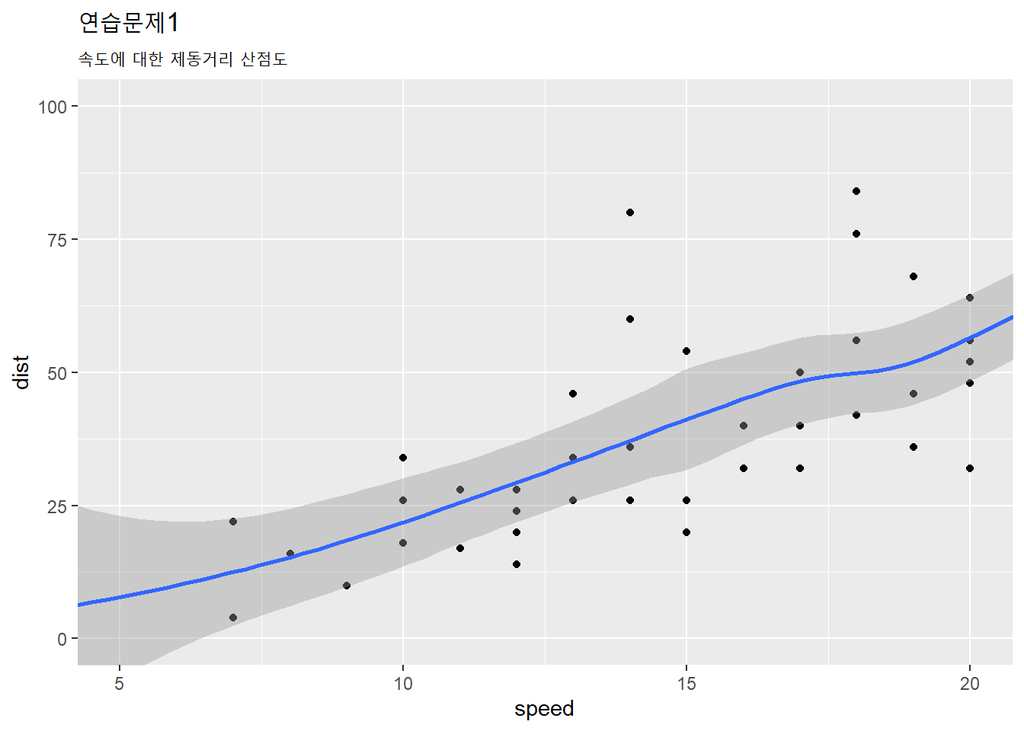

```r
library(ggplot2)
ggplot(cars,aes(x=speed, y=dist))+
  geom_point()+
  geom_smooth()+
  coord_cartesian(xlim=c(5,20), ylim=c(0,100))+
  labs(title="연습문제1",
       subtitle="속도에 대한 제동거리 산점도")
```

2. gapminder gapminder 데이터 셋을 이용하여 1 인당국내총생산에 대한 기대수명의 산점 도를 대륙별 다른 색으로 나타내시오

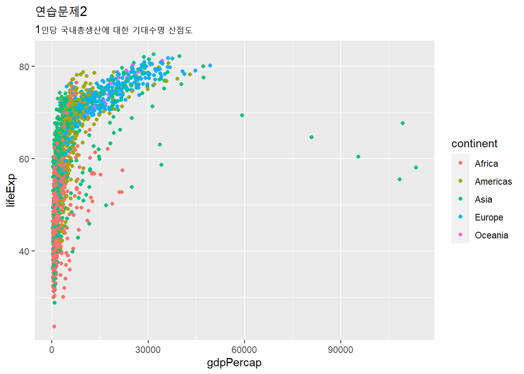

```r
library(gapminder)
ggplot(gapminder, aes(x=gdpPercap, y=lifeExp))+
  geom_point(aes(color=continent))+
  labs(title="연습문제2",
       subtitle="1인당 국내총생산에 대한 기대수명 산점도")
```

3. gapminder gapminder 데이터 셋을 이용하여 개대 수명이 70 을 초과하는 데이터에 대해 대륙별 데이터 갯수

```r
library(dplyr)
```

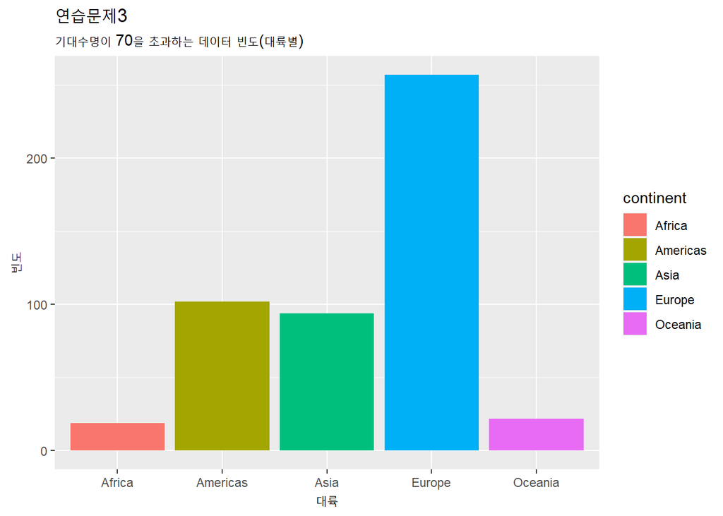

```r
gapminder %>%
  filter(lifeExp>=70) %>%
  group_by(continent) %>%
  summarise(n=n()) %>%
  ggplot(aes(x=continent, y=n))+
  geom_col(aes(fill=continent))+
  labs(x = "대륙",
       y="빈도",
       title="연습문제3",
       subtitle="기대수명이 70을 초과하는 데이터 빈도(대륙별)")
```

4. gapminder gapminder 데이터 셋을 이용하여 기대수명이 70 을 초과하는 데이터에 대해 대륙별 나라 갯수

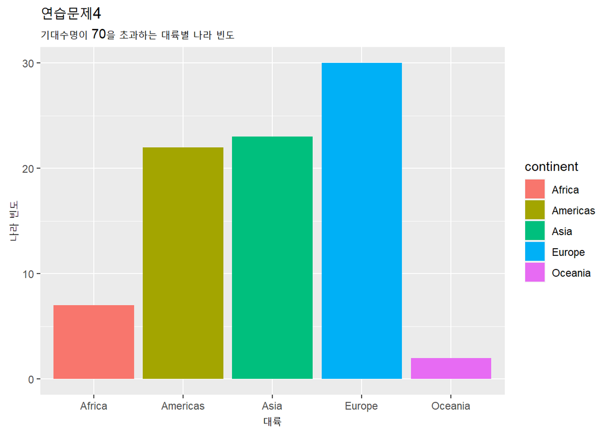

```r
gapminder %>%
  filter(lifeExp>=70) %>%
  group_by(continent) %>%
  summarise(n=n_distinct(country)) %>%
  ggplot(aes(x=continent, y=n))+
  geom_col(aes(fill=continent))+
  labs(x = "대륙",
       y="나라 빈도",
       title="연습문제4",
       subtitle="기대수명이 70을 초과하는 대륙별 나라 빈도")
```

5. gapminder gapminder 데이터 셋을 이용하여 대륙별 기대수명의 사분위수를 시각화

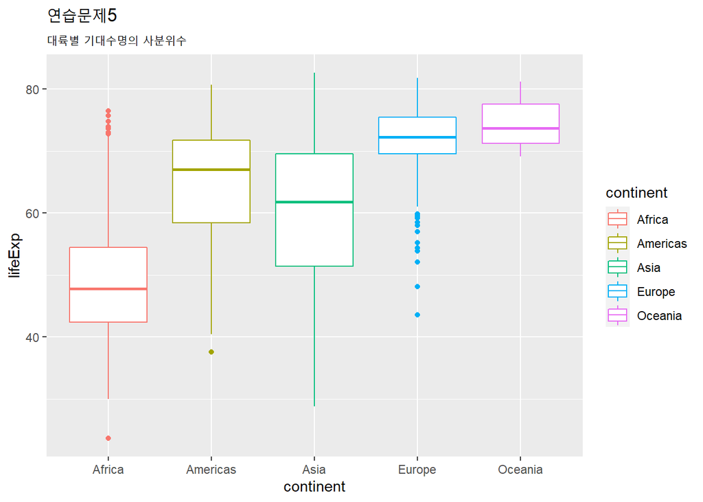

```r
ggplot(gapminder, aes(x=continent, y=lifeExp))+
  geom_boxplot(aes(color=continent))+
  labs(title="연습문제5",
       subtitle="대륙별 기대수명의 사분위수")
```

6. gapminder gapminder 데이터 셋을 이용하여 년도별로 gdp 와 기대수명과의 관계를 산점 도를 그리고 대륙별 점의 색상을 달리 시각화

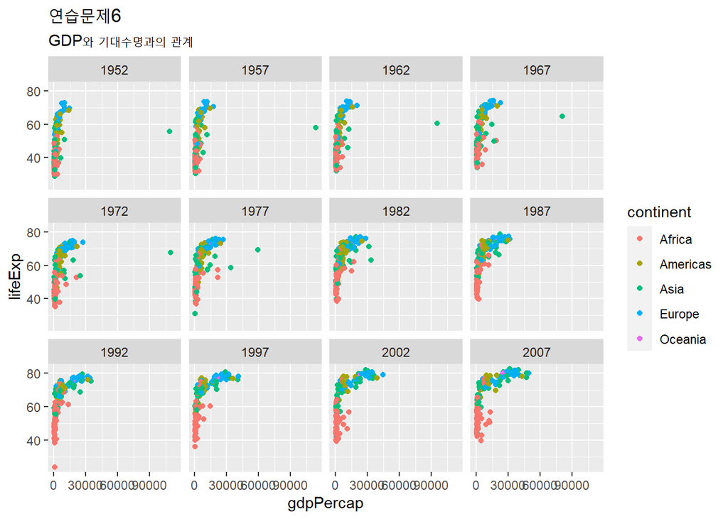

```r
ggplot(gapminder, aes(x=gdpPercap, y=lifeExp))+
  facet_wrap(~year)+
  geom_point(aes(color=continent))+
  labs(title="연습문제6",
       subtitle="GDP와 기대수명과의 관계")
```

7. gapminder gapminder 데이터 셋에서 북한과 한국의 년도별 GDP 변화를 산점도로 시각 화하시오 북한 :Korea, Dem. Rep. 한국 :Korea, Rep. substr str , start, 함수 이용

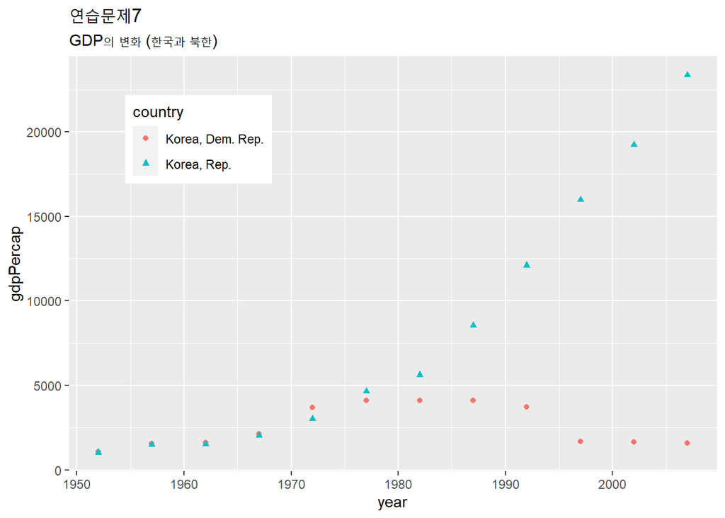

```r
gapminder %>%
  filter(country %in% c('Korea, Rep.', 'Korea, Dem. Rep.')) %>%
  ggplot(aes(x=year, y=gdpPercap))+
  geom_point(aes(color=country, pch=country))+
  labs(title="연습문제7",
       subtitle="GDP의 변화 (한국과 북한)")+
  theme(legend.position = c(0.2,0.8))
```

8. gapminder gapminder 데이터 셋을 이용하여 한중일 4 개국별 GDP 변화를 산점도와 추 세선으로 시각화 하시오

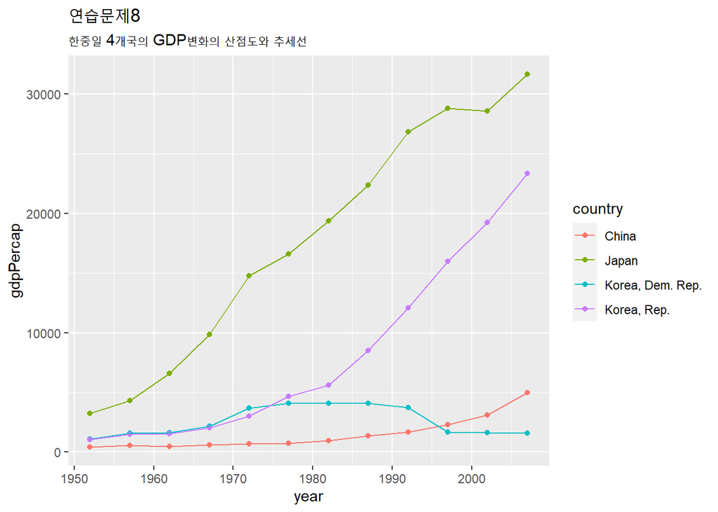

```r
gapminder %>%
  filter(country %in% c('Korea, Rep.', 'Korea, Dem. Rep.', 'China', 'Japan')) %>%
  ggplot(aes(x=year, y=gdpPercap))+
  geom_point(aes(color=country))+
  geom_line(aes(color=country))+
  labs(title="연습문제8",
       subtitle="한중일 4개국의 GDP변화의 산점도와 추세선")
```

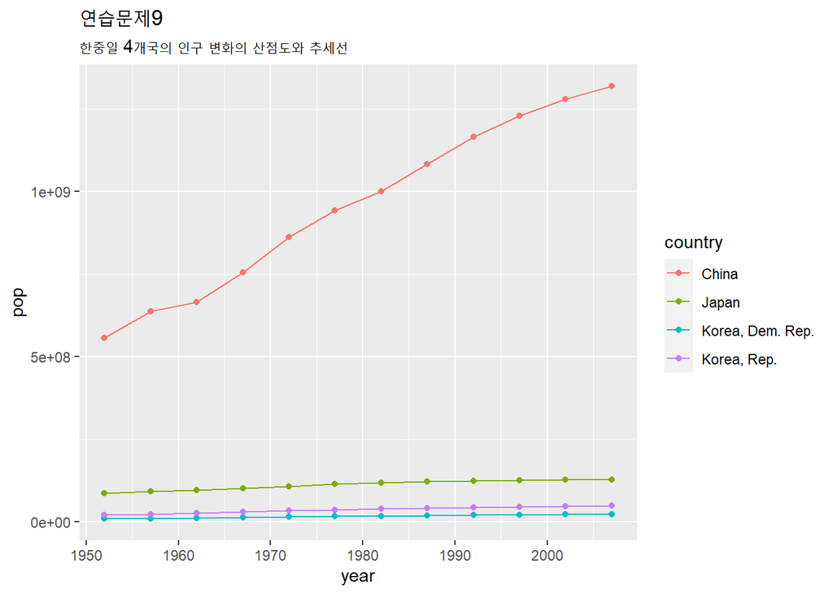

```r
gapminder %>%
  filter(country %in% c('Korea, Rep.', 'Korea, Dem. Rep.', 'China', 'Japan')) %>%
  ggplot(aes(x=year, y=pop))+
  geom_point(aes(color=country))+
  geom_line(aes(color=country))+
  labs(title="연습문제9",
       subtitle="한중일 4개국의 인구 변화의 산점도와 추세선")
```

10. Ggplot2::economic 데이터 셋의 개인 저축률 psavert 가 시간에 따라 어떻게 변해 왔는지 알아보려 한다 . 시간에 따른 개인 저축률의 변화를 나타낸 시계열 그래프와 추세선을 시각 화하시오

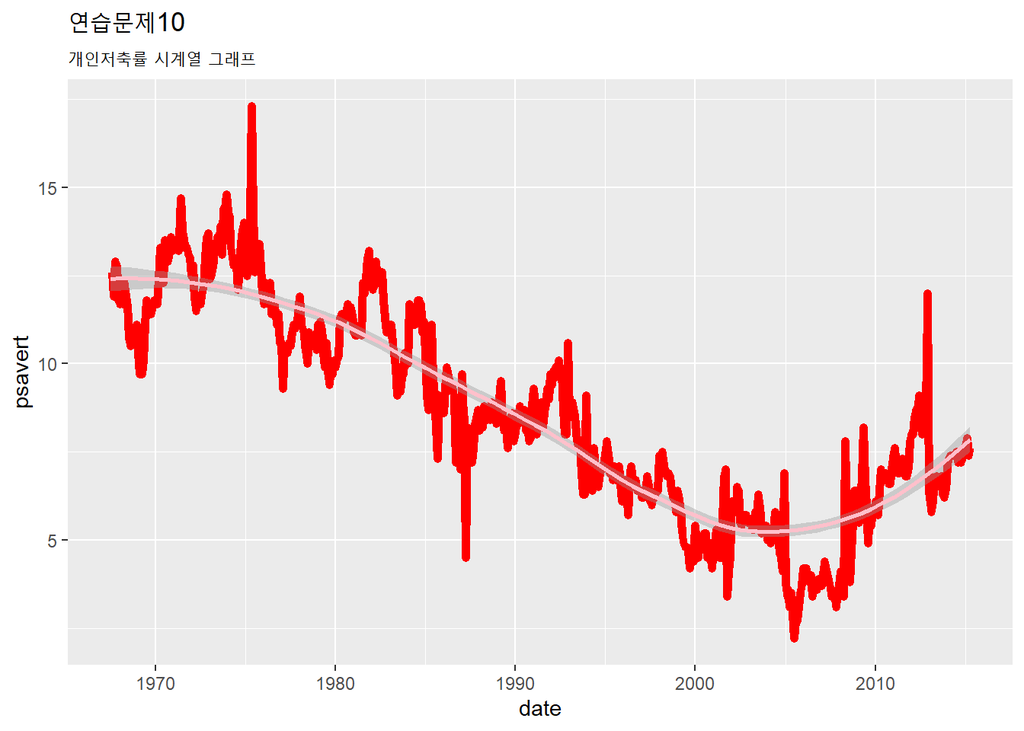

```r
ggplot(economics, aes(x=date, y=psavert))+
  geom_line(color="red", size=2)+
  geom_smooth(color="pink")+
  labs(title="연습문제10",
       subtitle="개인저축률 시계열 그래프")
```